# Bellabeat Analysis R Markdown

Shima Mojapelo

2025-04-25

# **PHASE 1: ASK**

Bellabeat is a high-tech manufacturer of health-focused products for women. As a data analyst in the marketing analyst team, I have been requested by Urška Sršen, cofounder and Chief Creative Officer of Bellabeat, to analyse smart device fitness data to identify potential growth opportunities for the company. THe objective is to gain insights into how consumers use their smart devices in order to help inform the marketing strategy.

Our main questions are: 1. What are some trends in smart device usage? 2. How could these trends apply to Bellabeat customers? 3. How could these trends help influence Bellabeat marketing strategy?

# **PHASE 2: PREPARE**

## Load the necessary packages and datasets into dataframes

```r
options(repos = "https://cran.r-project.org")

install.packages("tidyverse")
install.packages("dplyr")
```

```r
install.packages("ggplot2")
```

[output not shown]

```r
install.packages("lubridate")
install.packages("sqldf")
library(tidyverse)
```

```r
library(dplyr)
library(ggplot2)
library(lubridate)
library(sqldf)
```

## Load datasets from 3.12.16-4.11.16 into dataframes

```r
daily_Activity_merged1 <- read_csv("mturkfitbit_export_3.12.16-4.11.16/Fitabase Data 3.12.16-4.11.16/dailyActivity_merged.csv")
head(daily_Activity_merged1)
```

```
## # A tibble: 6 × 15
##           Id ActivityDate TotalSteps TotalDistance TrackerDistance
##        <dbl> <chr>             <dbl>         <dbl>           <dbl>
## 1 1503960366 3/25/2016         11004          7.11            7.11
## 2 1503960366 3/26/2016         17609         11.6            11.6
## 3 1503960366 3/27/2016         12736          8.53            8.53
## 4 1503960366 3/28/2016         13231          8.93            8.93
## 5 1503960366 3/29/2016         12041          7.85            7.85
## 6 1503960366 3/30/2016         10970          7.16            7.16
## # ℹ 10 more variables: LoggedActivitiesDistance <dbl>,
## #   VeryActiveDistance <dbl>, ModeratelyActiveDistance <dbl>,
## #   LightActiveDistance <dbl>, SedentaryActiveDistance <dbl>,
## #   VeryActiveMinutes <dbl>, FairlyActiveMinutes <dbl>,
## #   LightlyActiveMinutes <dbl>, SedentaryMinutes <dbl>, Calories <dbl>
```

```r
heartrate_seconds_merged1 <- read_csv("mturkfitbit_export_3.12.16-4.11.16/Fitabase Data 3.12.16-4.11.16/heartrate_seconds_merged.csv")
head(heartrate_seconds_merged1)
```

```
## # A tibble: 6 × 3
##           Id Time                Value
##        <dbl> <chr>               <dbl>
## 1 2022484408 4/1/2016 7:54:00 AM    93
## 2 2022484408 4/1/2016 7:54:05 AM    91
## 3 2022484408 4/1/2016 7:54:10 AM    96
## 4 2022484408 4/1/2016 7:54:15 AM    98
## 5 2022484408 4/1/2016 7:54:20 AM   100
## 6 2022484408 4/1/2016 7:54:25 AM   101
```

```r
hourlyCalories_merged1 <- read_csv("mturkfitbit_export_3.12.16-4.11.16/Fitabase Data 3.12.16-4.11.16/hourlyCalories_merged.csv")
head(hourlyCalories_merged1)
```

```
## # A tibble: 6 × 3
##           Id ActivityHour          Calories
##        <dbl> <chr>                    <dbl>
## 1 1503960366 3/12/2016 12:00:00 AM       48
## 2 1503960366 3/12/2016 1:00:00 AM        48
## 3 1503960366 3/12/2016 2:00:00 AM        48
## 4 1503960366 3/12/2016 3:00:00 AM        48
## 5 1503960366 3/12/2016 4:00:00 AM        48
## 6 1503960366 3/12/2016 5:00:00 AM        48
```

```r
hourlyIntensities_merged1 <- read_csv("mturkfitbit_export_3.12.16-4.11.16/Fitabase Data 3.12.16-4.11.16/hourlyIntensities_merged.csv")
head(hourlyIntensities_merged1)
```

```
## # A tibble: 6 × 4
##           Id ActivityHour          TotalIntensity AverageIntensity
##        <dbl> <chr>                          <dbl>            <dbl>
## 1 1503960366 3/12/2016 12:00:00 AM              0                0
## 2 1503960366 3/12/2016 1:00:00 AM               0                0
## 3 1503960366 3/12/2016 2:00:00 AM               0                0
## 4 1503960366 3/12/2016 3:00:00 AM               0                0
## 5 1503960366 3/12/2016 4:00:00 AM               0                0
## 6 1503960366 3/12/2016 5:00:00 AM               0                0
```

```r
hourlySteps_merged1 <- read_csv("mturkfitbit_export_3.12.16-4.11.16/Fitabase Data 3.12.16-4.11.16/hourlySteps_merged.csv")
head(hourlySteps_merged1)
```

```
## # A tibble: 6 × 3
##           Id ActivityHour          StepTotal
##        <dbl> <chr>                     <dbl>
## 1 1503960366 3/12/2016 12:00:00 AM         0
## 2 1503960366 3/12/2016 1:00:00 AM          0
## 3 1503960366 3/12/2016 2:00:00 AM          0
## 4 1503960366 3/12/2016 3:00:00 AM          0
## 5 1503960366 3/12/2016 4:00:00 AM          0
## 6 1503960366 3/12/2016 5:00:00 AM          0
```

```r
minuteCaloriesNarrow_merged1 <- read_csv("mturkfitbit_export_3.12.16-4.11.16/Fitabase Data 3.12.16-4.11.16/minuteCaloriesNarrow_merged.csv")
head(minuteCaloriesNarrow_merged1)
```

```
## # A tibble: 6 × 3
##           Id ActivityMinute        Calories
##        <dbl> <chr>                    <dbl>
## 1 1503960366 3/12/2016 12:00:00 AM    0.797
## 2 1503960366 3/12/2016 12:01:00 AM    0.797
## 3 1503960366 3/12/2016 12:02:00 AM    0.797
## 4 1503960366 3/12/2016 12:03:00 AM    0.797
## 5 1503960366 3/12/2016 12:04:00 AM    0.797
## 6 1503960366 3/12/2016 12:05:00 AM    0.797
```

```r
minuteIntensitiesNarrow_merged1 <- read_csv("mturkfitbit_export_3.12.16-4.11.16/Fitabase Data 3.12.16-4.11.16/minuteIntensitiesNarrow_merged.csv")
head(minuteIntensitiesNarrow_merged1)
```

```
## # A tibble: 6 × 3
##           Id ActivityMinute        Intensity
##        <dbl> <chr>                     <dbl>
## 1 1503960366 3/12/2016 12:00:00 AM         0
## 2 1503960366 3/12/2016 12:01:00 AM         0
## 3 1503960366 3/12/2016 12:02:00 AM         0
## 4 1503960366 3/12/2016 12:03:00 AM         0
## 5 1503960366 3/12/2016 12:04:00 AM         0
## 6 1503960366 3/12/2016 12:05:00 AM         0
```

```r
minuteMETsNarrow_merged1 <- read_csv("mturkfitbit_export_3.12.16-4.11.16/Fitabase Data 3.12.16-4.11.16/minuteMETsNarrow_merged.csv")
head(minuteMETsNarrow_merged1)
```

```
## # A tibble: 6 × 3
##           Id ActivityMinute         METs
##        <dbl> <chr>                 <dbl>
## 1 1503960366 3/12/2016 12:00:00 AM    10
## 2 1503960366 3/12/2016 12:01:00 AM    10
## 3 1503960366 3/12/2016 12:02:00 AM    10
## 4 1503960366 3/12/2016 12:03:00 AM    10
## 5 1503960366 3/12/2016 12:04:00 AM    10
## 6 1503960366 3/12/2016 12:05:00 AM    10
```

```r
minuteSleep_merged1 <- read_csv("mturkfitbit_export_3.12.16-4.11.16/Fitabase Data 3.12.16-4.11.16/minuteSleep_merged.csv")
head(minuteSleep_merged1)
```

```
## # A tibble: 6 × 4
##           Id date                 value       logId
##        <dbl> <chr>                <dbl>       <dbl>
## 1 1503960366 3/13/2016 2:39:30 AM     1 11114919637
## 2 1503960366 3/13/2016 2:40:30 AM     1 11114919637
## 3 1503960366 3/13/2016 2:41:30 AM     1 11114919637
## 4 1503960366 3/13/2016 2:42:30 AM     1 11114919637
## 5 1503960366 3/13/2016 2:43:30 AM     1 11114919637
## 6 1503960366 3/13/2016 2:44:30 AM     1 11114919637
```

```r
minuteStepsNarrow_merged1 <- read_csv("mturkfitbit_export_3.12.16-4.11.16/Fitabase Data 3.12.16-4.11.16/minuteStepsNarrow_merged.csv")
head(minuteStepsNarrow_merged1)
```

```
## # A tibble: 6 × 3
##           Id ActivityMinute        Steps
##        <dbl> <chr>                 <dbl>
## 1 1503960366 3/12/2016 12:00:00 AM     0
## 2 1503960366 3/12/2016 12:01:00 AM     0
## 3 1503960366 3/12/2016 12:02:00 AM     0
## 4 1503960366 3/12/2016 12:03:00 AM     0
## 5 1503960366 3/12/2016 12:04:00 AM     0
## 6 1503960366 3/12/2016 12:05:00 AM     0
```

```r
weightLogInfo_merged1 <- read_csv("mturkfitbit_export_3.12.16-4.11.16/Fitabase Data 3.12.16-4.11.16/weightLogInfo_merged.csv")
head(weightLogInfo_merged1)
```

```
## # A tibble: 6 × 8
##           Id Date       WeightKg WeightPounds   Fat   BMI IsManualReport   LogId
##        <dbl> <chr>         <dbl>        <dbl> <dbl> <dbl> <lgl>            <dbl>
## 1 1503960366 4/5/2016 …     53.3         118.    22  23.0 TRUE           1.46e12
## 2 1927972279 4/10/2016…    130.          286.    NA  46.2 FALSE          1.46e12
## 3 2347167796 4/3/2016 …     63.4         140.    10  24.8 TRUE           1.46e12
## 4 2873212765 4/6/2016 …     56.7         125.    NA  21.5 TRUE           1.46e12
## 5 2873212765 4/7/2016 …     57.2         126.    NA  21.6 TRUE           1.46e12
## 6 2891001357 4/5/2016 …     88.4         195.    NA  25.0 TRUE           1.46e12
```

## Load and preview datasets from 4.12.16-5.12.16 into data frames

```r
Daily_Activity2 <- read_csv("mturkfitbit_export_4.12.16-5.12.16/Fitabase Data 4.12.16-5.12.16/dailyActivity_merged.csv")
head(Daily_Activity2)
```

```
## # A tibble: 6 × 15
##           Id ActivityDate TotalSteps TotalDistance TrackerDistance
##        <dbl> <chr>             <dbl>         <dbl>           <dbl>
## 1 1503960366 4/12/2016         13162          8.5             8.5
## 2 1503960366 4/13/2016         10735          6.97            6.97
## 3 1503960366 4/14/2016         10460          6.74            6.74
## 4 1503960366 4/15/2016          9762          6.28            6.28
## 5 1503960366 4/16/2016         12669          8.16            8.16
## 6 1503960366 4/17/2016          9705          6.48            6.48
## # ℹ 10 more variables: LoggedActivitiesDistance <dbl>,
## #   VeryActiveDistance <dbl>, ModeratelyActiveDistance <dbl>,
## #   LightActiveDistance <dbl>, SedentaryActiveDistance <dbl>,
## #   VeryActiveMinutes <dbl>, FairlyActiveMinutes <dbl>,
## #   LightlyActiveMinutes <dbl>, SedentaryMinutes <dbl>, Calories <dbl>
```

```r
dailyCalories_merged2 <- read_csv("mturkfitbit_export_4.12.16-5.12.16/Fitabase Data 4.12.16-5.12.16/dailyCalories_merged.csv")
head(dailyCalories_merged2)
```

```
## # A tibble: 6 × 3
##           Id ActivityDay Calories
##        <dbl> <chr>          <dbl>
## 1 1503960366 4/12/2016       1985
## 2 1503960366 4/13/2016       1797
## 3 1503960366 4/14/2016       1776
## 4 1503960366 4/15/2016       1745
## 5 1503960366 4/16/2016       1863
## 6 1503960366 4/17/2016       1728
```

```r
dailyIntensities_merged2 <- read_csv("mturkfitbit_export_4.12.16-5.12.16/Fitabase Data 4.12.16-5.12.16/dailyIntensities_merged.csv")
head(dailyIntensities_merged2)
```

```
## # A tibble: 6 × 10
##         Id ActivityDay SedentaryMinutes LightlyActiveMinutes FairlyActiveMinutes
##      <dbl> <chr>                  <dbl>                <dbl>               <dbl>
## 1   1.50e9 4/12/2016                728                  328                  13
## 2   1.50e9 4/13/2016                776                  217                  19
## 3   1.50e9 4/14/2016               1218                  181                  11
## 4   1.50e9 4/15/2016                726                  209                  34
## 5   1.50e9 4/16/2016                773                  221                  10
## 6   1.50e9 4/17/2016                539                  164                  20
## # ℹ 5 more variables: VeryActiveMinutes <dbl>, SedentaryActiveDistance <dbl>,
## #   LightActiveDistance <dbl>, ModeratelyActiveDistance <dbl>,
## #   VeryActiveDistance <dbl>
```

```r
dailySteps_merged2 <- read_csv("mturkfitbit_export_4.12.16-5.12.16/Fitabase Data 4.12.16-5.12.16/dailySteps_merged.csv")
head(dailySteps_merged2)
```

```
## # A tibble: 6 × 3
##           Id ActivityDay StepTotal
##        <dbl> <chr>           <dbl>
## 1 1503960366 4/12/2016       13162
## 2 1503960366 4/13/2016       10735
## 3 1503960366 4/14/2016       10460
## 4 1503960366 4/15/2016        9762
## 5 1503960366 4/16/2016       12669
## 6 1503960366 4/17/2016        9705
```

```r
heartrate_seconds_merged2 <- read_csv("mturkfitbit_export_4.12.16-5.12.16/Fitabase Data 4.12.16-5.12.16/heartrate_seconds_merged.csv")
head(heartrate_seconds_merged2)
```

```
## # A tibble: 6 × 3
##           Id Time                 Value
##        <dbl> <chr>                <dbl>
## 1 2022484408 4/12/2016 7:21:00 AM    97
## 2 2022484408 4/12/2016 7:21:05 AM   102
## 3 2022484408 4/12/2016 7:21:10 AM   105
## 4 2022484408 4/12/2016 7:21:20 AM   103
## 5 2022484408 4/12/2016 7:21:25 AM   101
## 6 2022484408 4/12/2016 7:22:05 AM    95
```

```r
hourlyCalories_merged2 <- read_csv("mturkfitbit_export_4.12.16-5.12.16/Fitabase Data 4.12.16-5.12.16/hourlyCalories_merged.csv")
head(hourlyCalories_merged2)
```

```
## # A tibble: 6 × 3
##           Id ActivityHour          Calories
##        <dbl> <chr>                    <dbl>
## 1 1503960366 4/12/2016 12:00:00 AM       81
## 2 1503960366 4/12/2016 1:00:00 AM        61
## 3 1503960366 4/12/2016 2:00:00 AM        59
## 4 1503960366 4/12/2016 3:00:00 AM        47
## 5 1503960366 4/12/2016 4:00:00 AM        48
## 6 1503960366 4/12/2016 5:00:00 AM        48
```

```r
hourlyIntensities_merged2 <- read_csv("mturkfitbit_export_4.12.16-5.12.16/Fitabase Data 4.12.16-5.12.16/hourlyIntensities_merged.csv")
head(hourlyIntensities_merged2)
```

```
## # A tibble: 6 × 4
##           Id ActivityHour          TotalIntensity AverageIntensity
##        <dbl> <chr>                          <dbl>            <dbl>
## 1 1503960366 4/12/2016 12:00:00 AM             20            0.333
## 2 1503960366 4/12/2016 1:00:00 AM               8            0.133
## 3 1503960366 4/12/2016 2:00:00 AM               7            0.117
## 4 1503960366 4/12/2016 3:00:00 AM               0            0
## 5 1503960366 4/12/2016 4:00:00 AM               0            0
## 6 1503960366 4/12/2016 5:00:00 AM               0            0
```

```r
hourlySteps_merged2 <- read_csv("mturkfitbit_export_4.12.16-5.12.16/Fitabase Data 4.12.16-5.12.16/hourlySteps_merged.csv")
head(hourlySteps_merged2)
```

```
## # A tibble: 6 × 3
##           Id ActivityHour          StepTotal
##        <dbl> <chr>                     <dbl>
## 1 1503960366 4/12/2016 12:00:00 AM       373
## 2 1503960366 4/12/2016 1:00:00 AM        160
## 3 1503960366 4/12/2016 2:00:00 AM        151
## 4 1503960366 4/12/2016 3:00:00 AM          0
## 5 1503960366 4/12/2016 4:00:00 AM          0
## 6 1503960366 4/12/2016 5:00:00 AM          0
```

```r
minuteCaloriesNarrow_merged2 <- read_csv("mturkfitbit_export_4.12.16-5.12.16/Fitabase Data 4.12.16-5.12.16/minuteCaloriesNarrow_merged.csv")
head(minuteCaloriesNarrow_merged2)
```

```
## # A tibble: 6 × 3
##           Id ActivityMinute        Calories
##        <dbl> <chr>                    <dbl>
## 1 1503960366 4/12/2016 12:00:00 AM    0.786
## 2 1503960366 4/12/2016 12:01:00 AM    0.786
## 3 1503960366 4/12/2016 12:02:00 AM    0.786
## 4 1503960366 4/12/2016 12:03:00 AM    0.786
## 5 1503960366 4/12/2016 12:04:00 AM    0.786
## 6 1503960366 4/12/2016 12:05:00 AM    0.944
```

```r
minuteCaloriesWide_merged2 <- read_csv("mturkfitbit_export_4.12.16-5.12.16/Fitabase Data 4.12.16-5.12.16/minuteCaloriesWide_merged.csv")
head(minuteCaloriesWide_merged2)
```

```
## # A tibble: 6 × 62
##           Id ActivityHour Calories00 Calories01 Calories02 Calories03 Calories04
##        <dbl> <chr>             <dbl>      <dbl>      <dbl>      <dbl>      <dbl>
## 1 1503960366 4/13/2016 1…      1.89       2.20       0.944      0.944      0.944
## 2 1503960366 4/13/2016 1…      0.786      0.786      0.786      0.786      0.944
## 3 1503960366 4/13/2016 2…      0.786      0.786      0.786      0.786      0.786
## 4 1503960366 4/13/2016 3…      0.786      0.786      0.786      0.786      0.786
## 5 1503960366 4/13/2016 4…      0.786      0.786      0.786      0.786      0.786
## 6 1503960366 4/13/2016 5…      0.786      0.786      0.786      0.786      0.786
## # ℹ 55 more variables: Calories05 <dbl>, Calories06 <dbl>, Calories07 <dbl>,
## #   Calories08 <dbl>, Calories09 <dbl>, Calories10 <dbl>, Calories11 <dbl>,
## #   Calories12 <dbl>, Calories13 <dbl>, Calories14 <dbl>, Calories15 <dbl>,
## #   Calories16 <dbl>, Calories17 <dbl>, Calories18 <dbl>, Calories19 <dbl>,
## #   Calories20 <dbl>, Calories21 <dbl>, Calories22 <dbl>, Calories23 <dbl>,
## #   Calories24 <dbl>, Calories25 <dbl>, Calories26 <dbl>, Calories27 <dbl>,
## #   Calories28 <dbl>, Calories29 <dbl>, Calories30 <dbl>, Calories31 <dbl>, …
```

```r
minuteIntensitiesNarrow_merged2 <- read_csv("mturkfitbit_export_4.12.16-5.12.16/Fitabase Data 4.12.16-5.12.16/minuteIntensitiesNarrow_merged.csv")
head(minuteIntensitiesNarrow_merged2)
```

```
## # A tibble: 6 × 3
##           Id ActivityMinute        Intensity
##        <dbl> <chr>                     <dbl>
## 1 1503960366 4/12/2016 12:00:00 AM         0
## 2 1503960366 4/12/2016 12:01:00 AM         0
## 3 1503960366 4/12/2016 12:02:00 AM         0
## 4 1503960366 4/12/2016 12:03:00 AM         0
## 5 1503960366 4/12/2016 12:04:00 AM         0
## 6 1503960366 4/12/2016 12:05:00 AM         0
```

```r
minuteIntensitiesWide_merged2 <- read_csv("mturkfitbit_export_4.12.16-5.12.16/Fitabase Data 4.12.16-5.12.16/minuteIntensitiesWide_merged.csv")
head(minuteIntensitiesWide_merged2)
```

```
## # A tibble: 6 × 62
##           Id ActivityHour        Intensity00 Intensity01 Intensity02 Intensity03
##        <dbl> <chr>                     <dbl>       <dbl>       <dbl>       <dbl>
## 1 1503960366 4/13/2016 12:00:00…           1           1           0           0
## 2 1503960366 4/13/2016 1:00:00 …           0           0           0           0
## 3 1503960366 4/13/2016 2:00:00 …           0           0           0           0
## 4 1503960366 4/13/2016 3:00:00 …           0           0           0           0
## 5 1503960366 4/13/2016 4:00:00 …           0           0           0           0
## 6 1503960366 4/13/2016 5:00:00 …           0           0           0           0
## # ℹ 56 more variables: Intensity04 <dbl>, Intensity05 <dbl>, Intensity06 <dbl>,
## #   Intensity07 <dbl>, Intensity08 <dbl>, Intensity09 <dbl>, Intensity10 <dbl>,
## #   Intensity11 <dbl>, Intensity12 <dbl>, Intensity13 <dbl>, Intensity14 <dbl>,
## #   Intensity15 <dbl>, Intensity16 <dbl>, Intensity17 <dbl>, Intensity18 <dbl>,
## #   Intensity19 <dbl>, Intensity20 <dbl>, Intensity21 <dbl>, Intensity22 <dbl>,
## #   Intensity23 <dbl>, Intensity24 <dbl>, Intensity25 <dbl>, Intensity26 <dbl>,
## #   Intensity27 <dbl>, Intensity28 <dbl>, Intensity29 <dbl>, …
```

```r
minuteMETsNarrow_merged2 <- read_csv("mturkfitbit_export_4.12.16-5.12.16/Fitabase Data 4.12.16-5.12.16/minuteMETsNarrow_merged.csv")
head(minuteMETsNarrow_merged2)
```

```
## # A tibble: 6 × 3
##           Id ActivityMinute         METs
##        <dbl> <chr>                 <dbl>
## 1 1503960366 4/12/2016 12:00:00 AM    10
## 2 1503960366 4/12/2016 12:01:00 AM    10
## 3 1503960366 4/12/2016 12:02:00 AM    10
## 4 1503960366 4/12/2016 12:03:00 AM    10
## 5 1503960366 4/12/2016 12:04:00 AM    10
## 6 1503960366 4/12/2016 12:05:00 AM    12
```

```r
minuteSleep_merged2 <- read_csv("mturkfitbit_export_4.12.16-5.12.16/Fitabase Data 4.12.16-5.12.16/minuteSleep_merged.csv")
head(minuteSleep_merged2)
```

```
## # A tibble: 6 × 4
##           Id date                 value       logId
##        <dbl> <chr>                <dbl>       <dbl>
## 1 1503960366 4/12/2016 2:47:30 AM     3 11380564589
## 2 1503960366 4/12/2016 2:48:30 AM     2 11380564589
## 3 1503960366 4/12/2016 2:49:30 AM     1 11380564589
## 4 1503960366 4/12/2016 2:50:30 AM     1 11380564589
## 5 1503960366 4/12/2016 2:51:30 AM     1 11380564589
## 6 1503960366 4/12/2016 2:52:30 AM     1 11380564589
```

```r
minuteStepsNarrow_merged2 <- read_csv("mturkfitbit_export_4.12.16-5.12.16/Fitabase Data 4.12.16-5.12.16/minuteStepsNarrow_merged.csv")
head(minuteStepsNarrow_merged2)
```

```
## # A tibble: 6 × 3
##           Id ActivityMinute        Steps
##        <dbl> <chr>                 <dbl>
## 1 1503960366 4/12/2016 12:00:00 AM     0
## 2 1503960366 4/12/2016 12:01:00 AM     0
## 3 1503960366 4/12/2016 12:02:00 AM     0
## 4 1503960366 4/12/2016 12:03:00 AM     0
## 5 1503960366 4/12/2016 12:04:00 AM     0
## 6 1503960366 4/12/2016 12:05:00 AM     0
```

```r
minuteStepsWide_merged2 <- read_csv("mturkfitbit_export_4.12.16-5.12.16/Fitabase Data 4.12.16-5.12.16/minuteStepsWide_merged.csv")
head(minuteStepsWide_merged2)
```

```
## # A tibble: 6 × 62
##          Id ActivityHour Steps00 Steps01 Steps02 Steps03 Steps04 Steps05 Steps06
##       <dbl> <chr>          <dbl>   <dbl>   <dbl>   <dbl>   <dbl>   <dbl>   <dbl>
## 1    1.50e9 4/13/2016 1…       4      16       0       0       0       9       0
## 2    1.50e9 4/13/2016 1…       0       0       0       0       0       0       0
## 3    1.50e9 4/13/2016 2…       0       0       0       0       0       0       0
## 4    1.50e9 4/13/2016 3…       0       0       0       0       0       0       0
## 5    1.50e9 4/13/2016 4…       0       0       0       0       0       0       0
## 6    1.50e9 4/13/2016 5…       0       0       0       0       0       0       0
## # ℹ 53 more variables: Steps07 <dbl>, Steps08 <dbl>, Steps09 <dbl>,
## #   Steps10 <dbl>, Steps11 <dbl>, Steps12 <dbl>, Steps13 <dbl>, Steps14 <dbl>,
## #   Steps15 <dbl>, Steps16 <dbl>, Steps17 <dbl>, Steps18 <dbl>, Steps19 <dbl>,
## #   Steps20 <dbl>, Steps21 <dbl>, Steps22 <dbl>, Steps23 <dbl>, Steps24 <dbl>,
## #   Steps25 <dbl>, Steps26 <dbl>, Steps27 <dbl>, Steps28 <dbl>, Steps29 <dbl>,
## #   Steps30 <dbl>, Steps31 <dbl>, Steps32 <dbl>, Steps33 <dbl>, Steps34 <dbl>,
## #   Steps35 <dbl>, Steps36 <dbl>, Steps37 <dbl>, Steps38 <dbl>, …
```

```r
sleepDay_merged2 <- read_csv("mturkfitbit_export_4.12.16-5.12.16/Fitabase Data 4.12.16-5.12.16/sleepDay_merged.csv")
head(sleepDay_merged2)
```

```
## # A tibble: 6 × 5
##           Id SleepDay        TotalSleepRecords TotalMinutesAsleep TotalTimeInBed
##        <dbl> <chr>                       <dbl>              <dbl>          <dbl>
## 1 1503960366 4/12/2016 12:0…                 1                327            346
## 2 1503960366 4/13/2016 12:0…                 2                384            407
## 3 1503960366 4/15/2016 12:0…                 1                412            442
## 4 1503960366 4/16/2016 12:0…                 2                340            367
## 5 1503960366 4/17/2016 12:0…                 1                700            712
## 6 1503960366 4/19/2016 12:0…                 1                304            320
```

```r
weightLogInfo_merged2 <- read_csv("mturkfitbit_export_4.12.16-5.12.16/Fitabase Data 4.12.16-5.12.16/weightLogInfo_merged.csv")
head(weightLogInfo_merged2)
```

```
## # A tibble: 6 × 8
##           Id Date       WeightKg WeightPounds   Fat   BMI IsManualReport   LogId
##        <dbl> <chr>         <dbl>        <dbl> <dbl> <dbl> <lgl>            <dbl>
## 1 1503960366 5/2/2016 …     52.6         116.    22  22.6 TRUE           1.46e12
## 2 1503960366 5/3/2016 …     52.6         116.    NA  22.6 TRUE           1.46e12
## 3 1927972279 4/13/2016…    134.          294.    NA  47.5 FALSE          1.46e12
## 4 2873212765 4/21/2016…     56.7         125.    NA  21.5 TRUE           1.46e12
## 5 2873212765 5/12/2016…     57.3         126.    NA  21.7 TRUE           1.46e12
## 6 4319703577 4/17/2016…     72.4         160.    25  27.5 TRUE           1.46e12
```

## bind together related tables and sort by ID

```r
daily_Activity_merged <- rbind(daily_Activity_merged1, Daily_Activity2) %>%
  arrange(Id)
head(daily_Activity_merged)
```

```
## # A tibble: 6 × 15
##           Id ActivityDate TotalSteps TotalDistance TrackerDistance
##        <dbl> <chr>             <dbl>         <dbl>           <dbl>
## 1 1503960366 3/25/2016         11004          7.11            7.11
## 2 1503960366 3/26/2016         17609         11.6            11.6
## 3 1503960366 3/27/2016         12736          8.53            8.53
## 4 1503960366 3/28/2016         13231          8.93            8.93
## 5 1503960366 3/29/2016         12041          7.85            7.85
## 6 1503960366 3/30/2016         10970          7.16            7.16
## # ℹ 10 more variables: LoggedActivitiesDistance <dbl>,
## #   VeryActiveDistance <dbl>, ModeratelyActiveDistance <dbl>,
## #   LightActiveDistance <dbl>, SedentaryActiveDistance <dbl>,
## #   VeryActiveMinutes <dbl>, FairlyActiveMinutes <dbl>,
## #   LightlyActiveMinutes <dbl>, SedentaryMinutes <dbl>, Calories <dbl>
```

```r
dailyCalories_merged <- dailyCalories_merged2 %>%
  arrange(Id)
head(dailyCalories_merged)
```

```
## # A tibble: 6 × 3
##           Id ActivityDay Calories
##        <dbl> <chr>          <dbl>
## 1 1503960366 4/12/2016       1985
## 2 1503960366 4/13/2016       1797
## 3 1503960366 4/14/2016       1776
## 4 1503960366 4/15/2016       1745
## 5 1503960366 4/16/2016       1863
## 6 1503960366 4/17/2016       1728
```

```r
dailyIntensities_merged <- dailyIntensities_merged2 %>%
  arrange(Id)
head(dailyIntensities_merged)
```

```
## # A tibble: 6 × 10
##         Id ActivityDay SedentaryMinutes LightlyActiveMinutes FairlyActiveMinutes
##      <dbl> <chr>                  <dbl>                <dbl>               <dbl>
## 1   1.50e9 4/12/2016                728                  328                  13
## 2   1.50e9 4/13/2016                776                  217                  19
## 3   1.50e9 4/14/2016               1218                  181                  11
## 4   1.50e9 4/15/2016                726                  209                  34
## 5   1.50e9 4/16/2016                773                  221                  10
## 6   1.50e9 4/17/2016                539                  164                  20
## # ℹ 5 more variables: VeryActiveMinutes <dbl>, SedentaryActiveDistance <dbl>,
## #   LightActiveDistance <dbl>, ModeratelyActiveDistance <dbl>,
## #   VeryActiveDistance <dbl>
```

```r
dailySteps_merged <- dailySteps_merged2 %>%
  arrange(Id)
head(dailySteps_merged)
```

```
## # A tibble: 6 × 3
##           Id ActivityDay StepTotal
##        <dbl> <chr>           <dbl>
## 1 1503960366 4/12/2016       13162
## 2 1503960366 4/13/2016       10735
## 3 1503960366 4/14/2016       10460
## 4 1503960366 4/15/2016        9762
## 5 1503960366 4/16/2016       12669
## 6 1503960366 4/17/2016        9705
```

```r
heartrate_seconds_merged <- rbind(heartrate_seconds_merged1, heartrate_seconds_merged2) %>%
  arrange(Id)
head(heartrate_seconds_merged)
```

```
## # A tibble: 6 × 3
##           Id Time                Value
##        <dbl> <chr>               <dbl>
## 1 2022484408 4/1/2016 7:54:00 AM    93
## 2 2022484408 4/1/2016 7:54:05 AM    91
## 3 2022484408 4/1/2016 7:54:10 AM    96
## 4 2022484408 4/1/2016 7:54:15 AM    98
## 5 2022484408 4/1/2016 7:54:20 AM   100
## 6 2022484408 4/1/2016 7:54:25 AM   101
```

```r
hourlyCalories_merged <-rbind(hourlyCalories_merged1, hourlyCalories_merged2) %>%
  arrange(Id)
head(hourlyCalories_merged)
```

```
## # A tibble: 6 × 3
##           Id ActivityHour          Calories
##        <dbl> <chr>                    <dbl>
## 1 1503960366 3/12/2016 12:00:00 AM       48
## 2 1503960366 3/12/2016 1:00:00 AM        48
## 3 1503960366 3/12/2016 2:00:00 AM        48
## 4 1503960366 3/12/2016 3:00:00 AM        48
## 5 1503960366 3/12/2016 4:00:00 AM        48
## 6 1503960366 3/12/2016 5:00:00 AM        48
```

```r
hourlyIntensities_merged <- rbind(hourlyIntensities_merged1, hourlyIntensities_merged2) %>%
  arrange(Id)
head(hourlyIntensities_merged)
```

```
## # A tibble: 6 × 4
##           Id ActivityHour          TotalIntensity AverageIntensity
##        <dbl> <chr>                          <dbl>            <dbl>
## 1 1503960366 3/12/2016 12:00:00 AM              0                0
## 2 1503960366 3/12/2016 1:00:00 AM               0                0
## 3 1503960366 3/12/2016 2:00:00 AM               0                0
## 4 1503960366 3/12/2016 3:00:00 AM               0                0
## 5 1503960366 3/12/2016 4:00:00 AM               0                0
## 6 1503960366 3/12/2016 5:00:00 AM               0                0
```

```r
hourlySteps_merged <- rbind(hourlySteps_merged1, hourlySteps_merged2) %>%
  arrange(Id)
head(hourlySteps_merged)
```

```
## # A tibble: 6 × 3
##           Id ActivityHour          StepTotal
##        <dbl> <chr>                     <dbl>
## 1 1503960366 3/12/2016 12:00:00 AM         0
## 2 1503960366 3/12/2016 1:00:00 AM          0
## 3 1503960366 3/12/2016 2:00:00 AM          0
## 4 1503960366 3/12/2016 3:00:00 AM          0
## 5 1503960366 3/12/2016 4:00:00 AM          0
## 6 1503960366 3/12/2016 5:00:00 AM          0
```

```r
minuteCaloriesNarrow_merged <- rbind(minuteCaloriesNarrow_merged1, minuteCaloriesNarrow_merged2) %>%
  arrange(Id)
head(minuteCaloriesNarrow_merged)
```

```
## # A tibble: 6 × 3
##           Id ActivityMinute        Calories
##        <dbl> <chr>                    <dbl>
## 1 1503960366 3/12/2016 12:00:00 AM    0.797
## 2 1503960366 3/12/2016 12:01:00 AM    0.797
## 3 1503960366 3/12/2016 12:02:00 AM    0.797
## 4 1503960366 3/12/2016 12:03:00 AM    0.797
## 5 1503960366 3/12/2016 12:04:00 AM    0.797
## 6 1503960366 3/12/2016 12:05:00 AM    0.797
```

```r
minuteCaloriesWide_merged <- minuteCaloriesWide_merged2 %>%
  arrange(Id)
head(minuteCaloriesWide_merged)
```

```
## # A tibble: 6 × 62
##           Id ActivityHour Calories00 Calories01 Calories02 Calories03 Calories04
##        <dbl> <chr>             <dbl>      <dbl>      <dbl>      <dbl>      <dbl>
## 1 1503960366 4/13/2016 1…      1.89       2.20       0.944      0.944      0.944
## 2 1503960366 4/13/2016 1…      0.786      0.786      0.786      0.786      0.944
## 3 1503960366 4/13/2016 2…      0.786      0.786      0.786      0.786      0.786
## 4 1503960366 4/13/2016 3…      0.786      0.786      0.786      0.786      0.786
## 5 1503960366 4/13/2016 4…      0.786      0.786      0.786      0.786      0.786
## 6 1503960366 4/13/2016 5…      0.786      0.786      0.786      0.786      0.786
## # ℹ 55 more variables: Calories05 <dbl>, Calories06 <dbl>, Calories07 <dbl>,
## #   Calories08 <dbl>, Calories09 <dbl>, Calories10 <dbl>, Calories11 <dbl>,
## #   Calories12 <dbl>, Calories13 <dbl>, Calories14 <dbl>, Calories15 <dbl>,
## #   Calories16 <dbl>, Calories17 <dbl>, Calories18 <dbl>, Calories19 <dbl>,
## #   Calories20 <dbl>, Calories21 <dbl>, Calories22 <dbl>, Calories23 <dbl>,
## #   Calories24 <dbl>, Calories25 <dbl>, Calories26 <dbl>, Calories27 <dbl>,
## #   Calories28 <dbl>, Calories29 <dbl>, Calories30 <dbl>, Calories31 <dbl>, …
```

```r
minuteIntensitiesNarrow_merged <- rbind(minuteIntensitiesNarrow_merged1, minuteIntensitiesNarrow_merged2) %>%
  arrange(Id)
head(minuteIntensitiesNarrow_merged)
```

```
## # A tibble: 6 × 3
##           Id ActivityMinute        Intensity
##        <dbl> <chr>                     <dbl>
## 1 1503960366 3/12/2016 12:00:00 AM         0
## 2 1503960366 3/12/2016 12:01:00 AM         0
## 3 1503960366 3/12/2016 12:02:00 AM         0
## 4 1503960366 3/12/2016 12:03:00 AM         0
## 5 1503960366 3/12/2016 12:04:00 AM         0
## 6 1503960366 3/12/2016 12:05:00 AM         0
```

```r
minuteIntensitiesWide_merged<- minuteIntensitiesWide_merged2 %>%
  arrange(Id)
head(minuteIntensitiesWide_merged)
```

```
## # A tibble: 6 × 62
##           Id ActivityHour        Intensity00 Intensity01 Intensity02 Intensity03
##        <dbl> <chr>                     <dbl>       <dbl>       <dbl>       <dbl>
## 1 1503960366 4/13/2016 12:00:00…           1           1           0           0
## 2 1503960366 4/13/2016 1:00:00 …           0           0           0           0
## 3 1503960366 4/13/2016 2:00:00 …           0           0           0           0
## 4 1503960366 4/13/2016 3:00:00 …           0           0           0           0
## 5 1503960366 4/13/2016 4:00:00 …           0           0           0           0
## 6 1503960366 4/13/2016 5:00:00 …           0           0           0           0
## # ℹ 56 more variables: Intensity04 <dbl>, Intensity05 <dbl>, Intensity06 <dbl>,
## #   Intensity07 <dbl>, Intensity08 <dbl>, Intensity09 <dbl>, Intensity10 <dbl>,
## #   Intensity11 <dbl>, Intensity12 <dbl>, Intensity13 <dbl>, Intensity14 <dbl>,
## #   Intensity15 <dbl>, Intensity16 <dbl>, Intensity17 <dbl>, Intensity18 <dbl>,
## #   Intensity19 <dbl>, Intensity20 <dbl>, Intensity21 <dbl>, Intensity22 <dbl>,
## #   Intensity23 <dbl>, Intensity24 <dbl>, Intensity25 <dbl>, Intensity26 <dbl>,
## #   Intensity27 <dbl>, Intensity28 <dbl>, Intensity29 <dbl>, …
```

```r
minuteMETsNarrow_merged <- rbind(minuteMETsNarrow_merged1, minuteMETsNarrow_merged2) %>%
  arrange(Id)
head(minuteMETsNarrow_merged)
```

```
## # A tibble: 6 × 3
##           Id ActivityMinute         METs
##        <dbl> <chr>                 <dbl>
## 1 1503960366 3/12/2016 12:00:00 AM    10
## 2 1503960366 3/12/2016 12:01:00 AM    10
## 3 1503960366 3/12/2016 12:02:00 AM    10
## 4 1503960366 3/12/2016 12:03:00 AM    10
## 5 1503960366 3/12/2016 12:04:00 AM    10
## 6 1503960366 3/12/2016 12:05:00 AM    10
```

```r
minuteSleep_merged <- rbind(minuteSleep_merged1, minuteSleep_merged2) %>%
  arrange(Id)
head(minuteSleep_merged)
```

```
## # A tibble: 6 × 4
##           Id date                 value       logId
##        <dbl> <chr>                <dbl>       <dbl>
## 1 1503960366 3/13/2016 2:39:30 AM     1 11114919637
## 2 1503960366 3/13/2016 2:40:30 AM     1 11114919637
## 3 1503960366 3/13/2016 2:41:30 AM     1 11114919637
## 4 1503960366 3/13/2016 2:42:30 AM     1 11114919637
## 5 1503960366 3/13/2016 2:43:30 AM     1 11114919637
## 6 1503960366 3/13/2016 2:44:30 AM     1 11114919637
```

```r
minuteStepsNarrow_merged <- rbind(minuteStepsNarrow_merged1, minuteStepsNarrow_merged2) %>%
  arrange(Id)
head(minuteStepsNarrow_merged)
```

```
## # A tibble: 6 × 3
##           Id ActivityMinute        Steps
##        <dbl> <chr>                 <dbl>
## 1 1503960366 3/12/2016 12:00:00 AM     0
## 2 1503960366 3/12/2016 12:01:00 AM     0
## 3 1503960366 3/12/2016 12:02:00 AM     0
## 4 1503960366 3/12/2016 12:03:00 AM     0
## 5 1503960366 3/12/2016 12:04:00 AM     0
## 6 1503960366 3/12/2016 12:05:00 AM     0
```

```r
minuteStepsWide_merged <- minuteStepsWide_merged2 %>%
  arrange(Id)
head(minuteStepsWide_merged)
```

```
## # A tibble: 6 × 62
##          Id ActivityHour Steps00 Steps01 Steps02 Steps03 Steps04 Steps05 Steps06
##       <dbl> <chr>          <dbl>   <dbl>   <dbl>   <dbl>   <dbl>   <dbl>   <dbl>
## 1    1.50e9 4/13/2016 1…       4      16       0       0       0       9       0
## 2    1.50e9 4/13/2016 1…       0       0       0       0       0       0       0
## 3    1.50e9 4/13/2016 2…       0       0       0       0       0       0       0
## 4    1.50e9 4/13/2016 3…       0       0       0       0       0       0       0
## 5    1.50e9 4/13/2016 4…       0       0       0       0       0       0       0
## 6    1.50e9 4/13/2016 5…       0       0       0       0       0       0       0
## # ℹ 53 more variables: Steps07 <dbl>, Steps08 <dbl>, Steps09 <dbl>,
## #   Steps10 <dbl>, Steps11 <dbl>, Steps12 <dbl>, Steps13 <dbl>, Steps14 <dbl>,
## #   Steps15 <dbl>, Steps16 <dbl>, Steps17 <dbl>, Steps18 <dbl>, Steps19 <dbl>,
## #   Steps20 <dbl>, Steps21 <dbl>, Steps22 <dbl>, Steps23 <dbl>, Steps24 <dbl>,
## #   Steps25 <dbl>, Steps26 <dbl>, Steps27 <dbl>, Steps28 <dbl>, Steps29 <dbl>,
## #   Steps30 <dbl>, Steps31 <dbl>, Steps32 <dbl>, Steps33 <dbl>, Steps34 <dbl>,
## #   Steps35 <dbl>, Steps36 <dbl>, Steps37 <dbl>, Steps38 <dbl>, …
```

```r
sleepDay_merged <- sleepDay_merged2 %>%
  arrange(Id)
head(sleepDay_merged)
```

```
## # A tibble: 6 × 5
##           Id SleepDay        TotalSleepRecords TotalMinutesAsleep TotalTimeInBed
##        <dbl> <chr>                       <dbl>              <dbl>          <dbl>
## 1 1503960366 4/12/2016 12:0…                 1                327            346
## 2 1503960366 4/13/2016 12:0…                 2                384            407
## 3 1503960366 4/15/2016 12:0…                 1                412            442
## 4 1503960366 4/16/2016 12:0…                 2                340            367
## 5 1503960366 4/17/2016 12:0…                 1                700            712
## 6 1503960366 4/19/2016 12:0…                 1                304            320
```

```r
weightLogInfo_merged <- rbind(weightLogInfo_merged1, weightLogInfo_merged2) %>%
  arrange(Id)
head(weightLogInfo_merged)
```

```
## # A tibble: 6 × 8
##           Id Date       WeightKg WeightPounds   Fat   BMI IsManualReport   LogId
##        <dbl> <chr>         <dbl>        <dbl> <dbl> <dbl> <lgl>            <dbl>
## 1 1503960366 4/5/2016 …     53.3         118.    22  23.0 TRUE           1.46e12
## 2 1503960366 5/2/2016 …     52.6         116.    22  22.6 TRUE           1.46e12
## 3 1503960366 5/3/2016 …     52.6         116.    NA  22.6 TRUE           1.46e12
## 4 1927972279 4/10/2016…    130.          286.    NA  46.2 FALSE          1.46e12
## 5 1927972279 4/13/2016…    134.          294.    NA  47.5 FALSE          1.46e12
## 6 2347167796 4/3/2016 …     63.4         140.    10  24.8 TRUE           1.46e12
```

# **PHASE 3: PROCESS**

## Clear out any values that are less than or equal to zero

```r
daily_Activity_merged_no_zero <- daily_Activity_merged %>%
  filter(TotalSteps > 0 & TotalDistance > 0 & TrackerDistance > 0 & LoggedActivitiesDistance > 0 & Calories >0)

dailyCalories_merged_no_zero <- dailyCalories_merged %>%
  filter(Calories > 0)

dailyIntensities_merged_no_zero <- dailyIntensities_merged %>%
  filter(VeryActiveDistance > 0 | ModeratelyActiveDistance > 0 | LightActiveDistance > 0 | SedentaryActiveDistance > 0) %>%
  filter(VeryActiveMinutes > 0 | FairlyActiveMinutes > 0 | LightlyActiveMinutes > 0 | SedentaryMinutes > 0)

dailySteps_merged_no_zero <- dailySteps_merged %>%
  filter(StepTotal > 0)

heartrate_seconds_merged_no_zero <- heartrate_seconds_merged %>%
  filter(Value > 0)

hourlyCalories_merged_no_zero <- hourlyCalories_merged %>%
  filter(Calories > 0)

hourlyIntensities_merged_no_zero <- hourlyIntensities_merged %>%
  filter(TotalIntensity > 0 & AverageIntensity > 0)

hourlySteps_merged_no_zero <- hourlySteps_merged %>%
  filter(StepTotal > 0)

minuteCaloriesNarrow_merged_no_zero <- minuteCaloriesNarrow_merged %>%
  filter(Calories > 0)

minuteCaloriesWide_merged_no_zero <- minuteCaloriesWide_merged %>%
  filter(Calories01 > 0 | Calories02 > 0 | Calories03 > 0 | Calories04 > 0 | Calories05 > 0 | Calories06 > 0 | Calories07 > 0 | Calories08 > 0 | Calories09 > 0 | Calories10 > 0 | Calories11 > 0 | Calories12 > 0 | Calories13 > 0 | Calories14 > 0 | Calories15 > 0 | Calories16 > 0 | Calories17 > 0 | Calories18 > 0 | Calories19 > 0 | Calories20 > 0 | Calories21 > 0 | Calories22 > 0 | Calories23 > 0 | Calories24 > 0 | Calories25 > 0 | Calories26 > 0 | Calories27 > 0 | Calories28 > 0 | Calories29 > 0 | Calories30 > 0 | Calories31 > 0 | Calories32 > 0 | Calories33 > 0 | Calories34 > 0 | Calories35 > 0 | Calories36 > 0 | Calories37 > 0 | Calories38 > 0 | Calories39 > 0 | Calories40 > 0 | Calories41 > 0 | Calories42 > 0 | Calories43 > 0 | Calories44 > 0 | Calories45 > 0 | Calories46 > 0 | Calories47 > 0)

minuteIntensitiesNarrow_merged_no_zero <- minuteIntensitiesNarrow_merged %>%
  filter(Intensity > 0)

minuteIntensitiesWide_merged_no_zero <- minuteIntensitiesWide_merged %>%
  filter(Intensity01 > 0 | Intensity02 > 0 | Intensity03 > 0 | Intensity04 > 0 | Intensity05 > 0 | Intensity06 > 0 | Intensity07 > 0 | Intensity08 > 0 | Intensity09 > 0 | Intensity10 > 0 | Intensity11 > 0 | Intensity12 > 0 | Intensity13 > 0 | Intensity14 > 0 | Intensity15 > 0 | Intensity16 > 0 | Intensity17 > 0 | Intensity18 > 0 | Intensity19 > 0 | Intensity20 > 0 | Intensity21 > 0 | Intensity22 > 0 | Intensity23 > 0 | Intensity24 > 0 | Intensity25 > 0 | Intensity26 > 0 | Intensity27 > 0 | Intensity28 > 0 | Intensity29 > 0 | Intensity30 > 0 | Intensity31 > 0 | Intensity32 > 0 | Intensity33 > 0 | Intensity34 > 0 | Intensity35 > 0 | Intensity36 > 0 | Intensity37 > 0 | Intensity38 > 0 | Intensity39 > 0 | Intensity40 > 0 | Intensity41 > 0 | Intensity42 > 0 | Intensity43 > 0 | Intensity44 > 0 | Intensity45 > 0 | Intensity46 > 0 | Intensity47 > 0)

minuteMETsNarrow_merged_no_zero <- minuteMETsNarrow_merged %>%
  filter(METs > 0)

minuteSleep_merged_no_zero <- minuteSleep_merged %>%
  filter(value > 0)

minuteStepsNarrow_merged_no_zero <- minuteStepsNarrow_merged %>%
  filter(Steps > 0)

minuteStepsWide_merged_no_zero <- minuteStepsWide_merged %>%
  filter(Steps01 > 0 | Steps02 > 0 | Steps03 > 0 | Steps04 > 0 | Steps05 > 0 | Steps06 > 0 | Steps07 > 0 | Steps08 > 0 | Steps09 > 0 | Steps10 > 0 | Steps11 > 0 | Steps12 > 0 | Steps13 > 0 | Steps14 > 0 | Steps15 > 0 | Steps16 > 0 | Steps17 > 0 | Steps18 > 0 | Steps19 > 0 | Steps20 > 0 | Steps21 > 0 | Steps22 > 0 | Steps23 > 0 | Steps24 > 0 | Steps25 > 0 | Steps26 > 0 | Steps27 > 0 | Steps28 > 0 | Steps29 > 0 | Steps30 > 0 | Steps31 > 0 | Steps32 > 0 | Steps33 > 0 | Steps34 > 0 | Steps35 > 0 | Steps36 > 0 | Steps37 > 0 | Steps38 > 0 | Steps39 > 0 | Steps40 > 0 | Steps41 > 0 | Steps42 > 0 | Steps43 > 0 | Steps44 > 0 | Steps45 > 0 | Steps46 > 0 | Steps47 > 0)

sleepDay_merged_no_zero <- sleepDay_merged %>%
  filter(TotalSleepRecords > 0 & TotalMinutesAsleep > 0 & TotalTimeInBed > 0)

weightLogInfo_merged_no_zero <- weightLogInfo_merged %>%
  filter(WeightKg > 0 & WeightPounds > 0 & BMI > 0)
```

## Set value in minute sleep should be 1

Value in minuteSleep_merged table should be 1 (You can literally only sleep for 1 minute “in a minute”)

```r
minuteSleep_merged_no_zero$value[minuteSleep_merged_no_zero$value != 1] <- 1
```

## Standardise clean dataframe names

```r
daily_Activity_cleaned <- daily_Activity_merged_no_zero
minuteSleep_cleaned <- minuteSleep_merged_no_zero
dailyCalories_cleaned <- dailyCalories_merged_no_zero
dailyIntensities_cleaned <- dailyIntensities_merged_no_zero
dailySteps_cleaned <- dailySteps_merged_no_zero
heartrate_seconds_cleaned <- heartrate_seconds_merged_no_zero
hourlyCalories_cleaned <- hourlyCalories_merged_no_zero
hourlyIntensities_cleaned <- hourlyIntensities_merged_no_zero
hourlySteps_cleaned <- hourlySteps_merged_no_zero
minuteCaloriesNarrow_cleaned <- minuteCaloriesNarrow_merged_no_zero
minuteCaloriesWide_cleaned <- minuteCaloriesWide_merged_no_zero
minuteIntensitiesNarrow_cleaned <- minuteIntensitiesNarrow_merged_no_zero
minuteIntensitiesWide_cleaned <- minuteIntensitiesWide_merged_no_zero
minuteMETsNarrow_cleaned <- minuteMETsNarrow_merged_no_zero
minuteSleep_cleaned <- minuteSleep_merged_no_zero
minuteStepsNarrow_cleaned <- minuteStepsNarrow_merged_no_zero
minuteStepsWide_cleaned <- minuteStepsWide_merged_no_zero
sleepDay_cleaned <- sleepDay_merged_no_zero
weightLogInfo_cleaned <- weightLogInfo_merged_no_zero
```

## Prepare CSV files for Visualisation

```r
write.csv(daily_Activity_cleaned, "Processing Visualisations/Data/daily_Activity_cleaned.csv")
write.csv(minuteSleep_cleaned, "Processing Visualisations/Data/minuteSleep_cleaned.csv")
write.csv(dailyCalories_cleaned, "Processing Visualisations/Data/dailyCalories_cleaned.csv")
write.csv(dailyIntensities_cleaned, "Processing Visualisations/Data/dailyIntensities_cleaned.csv")
write.csv(dailySteps_cleaned, "Processing Visualisations/Data/dailySteps_cleaned.csv")
write.csv(heartrate_seconds_cleaned, "Processing Visualisations/Data/heartrate_seconds_cleaned.csv")
write.csv(hourlyCalories_cleaned, "Processing Visualisations/Data/hourlyCalories_cleaned.csv")
write.csv(hourlyIntensities_cleaned, "Processing Visualisations/Data/hourlyIntensities_cleaned.csv")
write.csv(hourlySteps_cleaned, "Processing Visualisations/Data/hourlySteps_cleaned.csv")
write.csv(minuteCaloriesNarrow_cleaned, "Processing Visualisations/Data/minuteCaloriesNarrow_cleaned.csv")
write.csv(minuteCaloriesWide_cleaned, "Processing Visualisations/Data/minuteCaloriesWide_cleaned.csv")
write.csv(minuteIntensitiesNarrow_cleaned, "Processing Visualisations/Data/minuteIntensitiesNarrow_cleaned.csv")
write.csv(minuteIntensitiesWide_cleaned, "Processing Visualisations/Data/minuteIntensitiesWide_cleaned.csv")
write.csv(minuteMETsNarrow_cleaned, "Processing Visualisations/Data/minuteMETsNarrow_cleaned.csv")
write.csv(minuteSleep_cleaned, "Processing Visualisations/Data/minuteSleep_cleaned.csv")
write.csv(minuteStepsNarrow_cleaned, "Processing Visualisations/Data/minuteStepsNarrow_cleaned.csv")
write.csv(minuteStepsWide_cleaned, "Processing Visualisations/Data/minuteStepsWide_cleaned.csv")
write.csv(sleepDay_cleaned, "Processing Visualisations/Data/sleepDay_cleaned.csv")
write.csv(weightLogInfo_cleaned, "Processing Visualisations/Data/weightLogInfo_cleaned.csv")
```

# **PHASE 4: ANALYSE**

## Calculate Totals on Different Devices

```r
Daily_Activity_Device_Totals <- summarise(daily_Activity_cleaned, Total_Minutes_From_daily_Activity_Device = sum(VeryActiveMinutes, FairlyActiveMinutes, LightlyActiveMinutes, SedentaryMinutes), Total_Distance_From_daily_Activity_Device = sum(VeryActiveDistance, ModeratelyActiveDistance, LightActiveDistance, SedentaryActiveDistance))

head(Daily_Activity_Device_Totals)
```

```
## # A tibble: 1 × 2
##   Total_Minutes_From_daily_Activity_Device Total_Distance_From_daily_Activity_…¹
##                                      <dbl>                                 <dbl>
## 1                                    60446                                  461.
## # ℹ abbreviated name: ¹Total_Distance_From_daily_Activity_Device
```

```r
Daily_Intensities_Device_Totals <- summarise(dailyIntensities_cleaned, Total_Minutes_From_daily_Intensities_Device = sum(VeryActiveMinutes, FairlyActiveMinutes, LightlyActiveMinutes, SedentaryMinutes), Total_Distance_From_daily_Intensities_Device = sum(VeryActiveDistance, ModeratelyActiveDistance, LightActiveDistance, SedentaryActiveDistance))

head(Daily_Intensities_Device_Totals)
```

```
## # A tibble: 1 × 2
##   Total_Minutes_From_daily_Intensities_Device Total_Distance_From_daily_Intens…¹
##                                         <dbl>                              <dbl>
## 1                                     1027152                              5088.
## # ℹ abbreviated name: ¹Total_Distance_From_daily_Intensities_Device
```

## Visualise Data

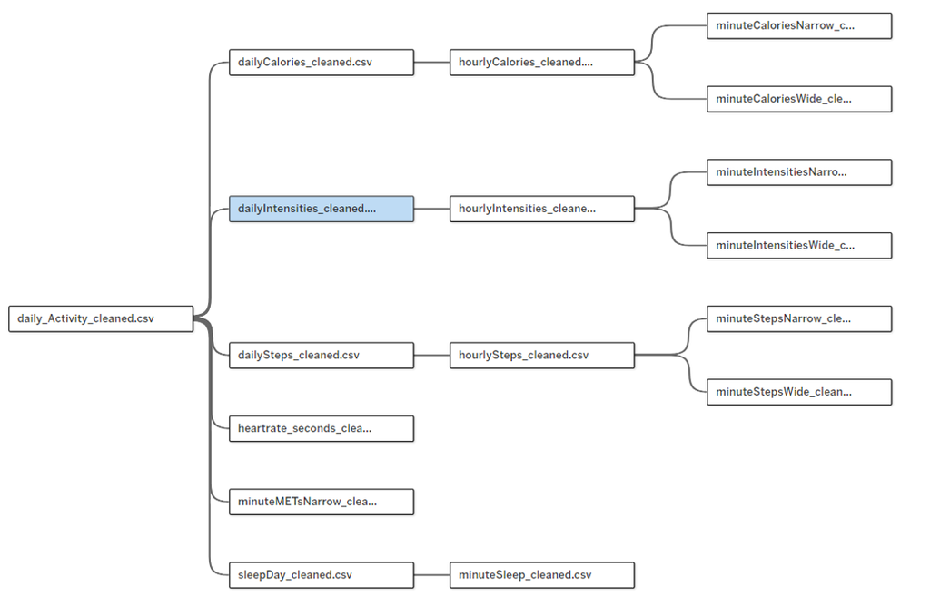

## Filter Data

After looking at the relationship map we are able to see that the most effective and efficient course of action is to look at daily data a lot of the other tables (hourly data, minute data, seconds data, wide data, narrow data) are create a lot of unnecessary noise.

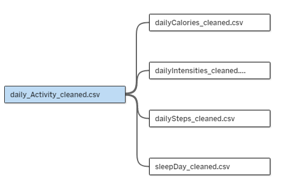

A visualisation of the cleaned relationship map created

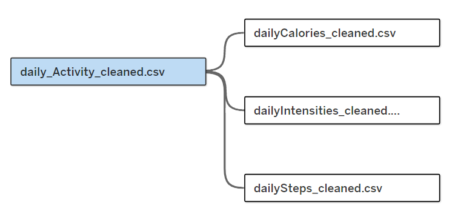

A visualisation of the final relationship map created

[figure not shown]

```javascript
var divElement = document.getElementById('viz1745842154835');
var vizElement = divElement.getElementsByTagName('object')[0];
vizElement.style.width='1169px';vizElement.style.height='854px';
var scriptElement = document.createElement('script');
scriptElement.src = 'https://public.tableau.com/javascripts/api/viz_v1.js';
vizElement.parentNode.insertBefore(scriptElement, vizElement);
```

## **PHASE 5: SHARE INSIGHTS**

**Insight:** Most of the minutes captured are classified as “Sedentary” **Implication:** Customers using devices are sedentary most of the time **Recommendation:** Develop a marketing strategy targeted for customers who use products while sedentary (e.g for people at work or in class)

**Insight:** More records are captured on most devices during the weekend **Implication:** Customers use devices more frequently on weekends **Recommendation:** Develop a marketing strategy targeted for customers who use products during the weekend during weekends